# **Geospatial Data Sciences and Economic Spatial Models** *Assignment 03*

1. Alejandro Delgado** **2. Enzo Infantes** **3. Tarang Kadyan** **4. Matias Borrell

2025-03-03

[figure not shown]

```r
library(sf)
library(spData)
library(tidyverse)
library(ggplot2)
library(terra)
library(exactextractr)
library(dplyr)
library(leaflet)

setwd("C:/Users/Enzo/Documents/BSE/T2/GEOSPATIAL_SPATIAL_MODELS/S08/HW")
path <- getwd()
path_data <- file.path(path, "data")
```

# 1 **Raster spatial data and interactive tools**

In this project, we will present Take-Home Assignment 03. The main points we will cover are:

1. Climate change in the USA
2. Transportation centrality

In the following section, we will outline the development process.

# 2 **Development**

## 2.1 **Climate change in the USA**

In this section, we are uploading all the data that will be used in the following steps.

```r
#sink(tempfile())

# Importing us_states data
sf.usstates <- us_states
# Load as a raster
SPEI_US_data <- rast(file.path(path_data, 'spei01.nc'))
# Matching coordinate system
# Check and match the CRS (Coordinate Reference System)
us_states <- st_transform(us_states, crs(SPEI_US_data))

#sink()
```

We are calculating the average SPEI index across regions over the past 50 years.

```r
# Aggregating data by region
sink(tempfile())
# Dissolve state polygons into regional polygons
us_regions <- us_states %>%
  group_by(REGION) %>%
  summarise(geometry = st_union(geometry), .groups = "drop")

# Getting raster time information
time_info <- time(SPEI_US_data)

# Find the index of the first occurrence of "1966"
start_index <- which(grepl("^1966", time_info))[1]

# Select last 50 years (~600 months)
end_index <- start_index + 599

# Select raster layers from 1966 to 2015
SPEI_recent <- SPEI_US_data[[start_index:end_index]]

spei_list <- list()

for (i in 1:50) {
  # Compute mean over 12 months first
  yearly_spei_mean <- app(SPEI_recent[[((i-1) * 12 + 1):(i * 12)]], mean)

  # Extract mean SPEI per region for the year
  spei_mean <- exact_extract(yearly_spei_mean, us_regions, fun = "mean")

  spei_list[[i]] <- spei_mean
}
sink()

# Convert to matrix
spei_matrix <- do.call(cbind, spei_list)

# Check dimensions
# dim(spei_matrix)  # dim return (4, 50)

# Add column names for each year
colnames(spei_matrix) <- paste0(1966:2015)

# Attach SPEI data to `us_regions`
us_regions_spei <- cbind(us_regions, spei_matrix)
# Remove the "X" prefix from numeric column names
colnames(us_regions_spei) <- gsub("^X", "", colnames(us_regions_spei))


# Convert sf object to a normal data frame
df_normal <- us_regions_spei %>% st_drop_geometry()

# Ensure column names are properly formatted as characters
colnames(df_normal) <- as.character(colnames(df_normal))

print(colnames(df_normal))
```

```
##  [1] "REGION" "1966"   "1967"   "1968"   "1969"   "1970"   "1971"   "1972"
##  [9] "1973"   "1974"   "1975"   "1976"   "1977"   "1978"   "1979"   "1980"
## [17] "1981"   "1982"   "1983"   "1984"   "1985"   "1986"   "1987"   "1988"
## [25] "1989"   "1990"   "1991"   "1992"   "1993"   "1994"   "1995"   "1996"
## [33] "1997"   "1998"   "1999"   "2000"   "2001"   "2002"   "2003"   "2004"
## [41] "2005"   "2006"   "2007"   "2008"   "2009"   "2010"   "2011"   "2012"
## [49] "2013"   "2014"   "2015"
```

```r
# Apply pivot_longer() after removing geometry
df_long <- df_normal %>%
  pivot_longer(
    cols = -REGION,    # Exclude the "REGION" column
    names_to = "Year",  # Column names become "Year"
    values_to = "Value", # Values go into "Value"
    values_drop_na = TRUE
  ) %>%
  mutate(Year = as.integer(Year))  # Convert Year column to numeric if needed
```

Finally, we can observe the figure showing the evolution of the SPEI index for each region.

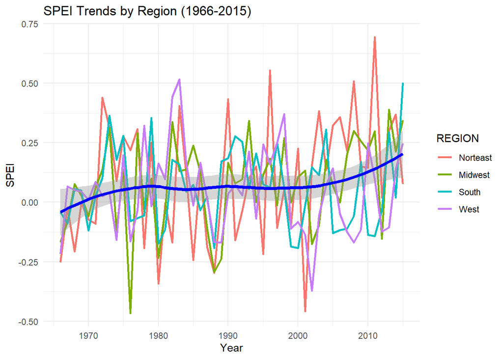

```r
ggplot(df_long, aes(x = Year, y = Value, color = REGION)) +
  geom_line(size = 1) +  # Line plot for each region
  geom_smooth(method = "loess", color = "blue", size = 1.5, se = TRUE) +  # Smoothed trend line
  theme_minimal() +
  labs(title = "SPEI Trends by Region (1966-2015)",
       x = "Year",
       y = "SPEI",
       color = "REGION") +
  theme(legend.position = "right")
```

## 2.2 **Transportation centrality**

Similarly to the previous question, we need to upload the data to solve these questions. In this case, we are using data for roads, populated places, the world, etc.

Also, we will be retrieving the top 10 most populated cities in Spain.

```r
sink(tempfile())

populated_places <- st_read(file.path(path_data, 'ne_10m_populated_places/ne_10m_populated_places.shp'))

roads <- st_read(file.path(path_data, "ne_10m_roads/ne_10m_roads.shp"))

ne1_raster <- rast(file.path(path_data, 'NE1_HR_LC/NE1_HR_LC.tif'))

world <- st_read((system.file('shapes/world.gpkg', package = 'spData')))
sink()

#Filtering:
spain_border <- world %>% filter(name_long == 'Spain')

spain_cities <- populated_places %>%
  filter(ISO_A2 == 'ES') %>%
  arrange(desc(POP_MAX)) %>%
  slice(1:10)

print(spain_cities['NAME'])
```

```
## Simple feature collection with 10 features and 1 field
## Geometry type: POINT
## Dimension:     XY
## Bounding box:  xmin: -8.729994 ymin: 36.72041 xmax: 2.181424 ymax: 43.24998
## Geodetic CRS:  WGS 84
##         NAME                    geometry
## 1     Madrid  POINT (-3.685297 40.40197)
## 2  Barcelona   POINT (2.181424 41.38525)
## 3    Seville  POINT (-5.980007 37.40502)
## 4     Bilbao  POINT (-2.929987 43.24998)
## 5   Valencia POINT (-0.4019579 39.48696)
## 6   Zaragoza    POINT (-0.8899821 41.65)
## 7     Málaga  POINT (-4.419999 36.72041)
## 8     Murcia  POINT (-1.129968 37.97999)
## 9    Granada  POINT (-3.585011 37.16498)
## 10      Vigo  POINT (-8.729995 42.22002)
```

Moreover, in the following figure, we can see the cropped roads data within Spain’s borders.

```r
spain_roads_cropped <- st_intersection(roads, spain_border)
```

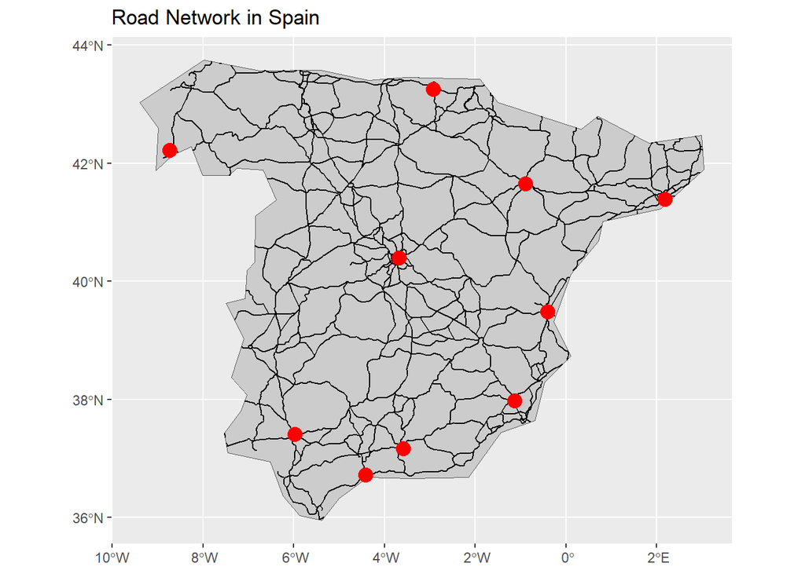

```r
ggplot() +
  geom_sf(data = spain_border, fill = "gray80") +
  geom_sf(data = spain_roads_cropped, color = "black", size = 0.2) +
  geom_sf(data = spain_cities, color = 'red', size = 4) +
  ggtitle("Road Network in Spain")
```

We are replicating the graph shown in the instructions. We have done it with Madrid and Vigo.

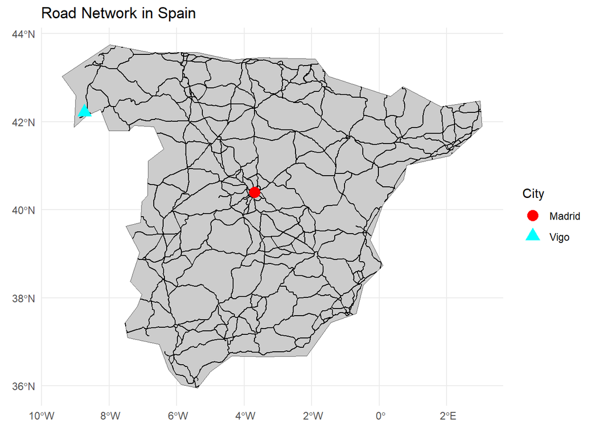

```r
sink(tempfile())
# Define the top 10 cities to plot
graph_cities <- c("Madrid", "Vigo")

# Filter the cities
spain_cities_graph <- spain_cities %>% filter(NAME %in% graph_cities)

# Assign unique markers (shapes) to each city
city_shapes <- c("Madrid" = 16, "Vigo" = 17)

# Assign colors for better visualization
city_colors <- c("Madrid" = "red", "Vigo" = 'cyan')
sink()

# Plot the map with different markers
ggplot() +
  geom_sf(data = spain_border, fill = "gray80") +  # Spain's border
  geom_sf(data = spain_roads_cropped, color = "black", size = 0.2) +  # Roads
  geom_sf(data = spain_cities_graph,
          aes(color = NAME, shape = NAME), size = 4) +  # Cities with different markers
  scale_shape_manual(values = city_shapes) +  # Assigning shapes
  scale_color_manual(values = city_colors) +  # Assigning colors
  labs(title = "Road Network in Spain", color = "City", shape = "City") +  # Legend
  theme_minimal()
```

Rasterizing:

```r
ne1_raster_line <- ne1_raster[[1]]

spain_border <- st_transform(spain_border, crs(ne1_raster_line))

ne1_raster_cropped <- crop(ne1_raster_line, ext(spain_border))

# Masking to get rid of the surroundings
ne1_raster_masked <- mask(ne1_raster_cropped, vect(spain_border))

# Convert city coordinates to spatial points
city_points <- st_as_sf(spain_cities, coords = c("longitude", "latitude"), crs = st_crs(friction_surface))

city_points_vect <- vect(city_points)


# Extract values from the raster at city locations
city_raster_values <- extract(ne1_raster_masked, city_points_vect)

# Convert to a data frame for easier viewing
city_raster_df <- data.frame(
  City = spain_cities$NAMEASCII,
  Raster_Value = city_raster_values
)

# Print extracted raster values for each city
print(city_raster_df)
```

```
##         City Raster_Value.ID Raster_Value.NE1_HR_LC_1
## 1     Madrid               1                      226
## 2  Barcelona               2                      221
## 3    Seville               3                      235
## 4     Bilbao               4                      224
## 5   Valencia               5                      235
## 6   Zaragoza               6                      236
## 7     Malaga               7                      225
## 8     Murcia               8                      232
## 9    Granada               9                      231
## 10      Vigo              10                      228
```

Figure showing raster values and city locations based on our previous data (Spain).

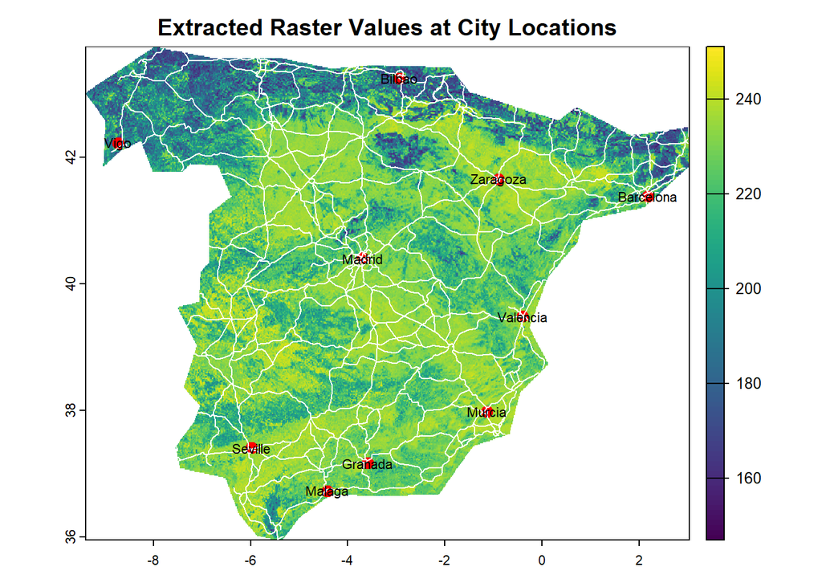

```r
plot(ne1_raster_masked, main = "Extracted Raster Values at City Locations")

plot(st_geometry(city_points), add = TRUE, col = "red", pch = 20, cex = 2)

plot(st_geometry(spain_roads_cropped), add = TRUE, col = "white")

text(st_coordinates(city_points), labels = city_raster_df$City, cex = 0.7, col = "black")
```

Distances between all City Pairs.

```r
# Compute the geographic distance raster
geo_distance_raster <- distance(ne1_raster_masked, city_points_vect)
```

```
## |---------|---------|---------|---------|=========================================
```

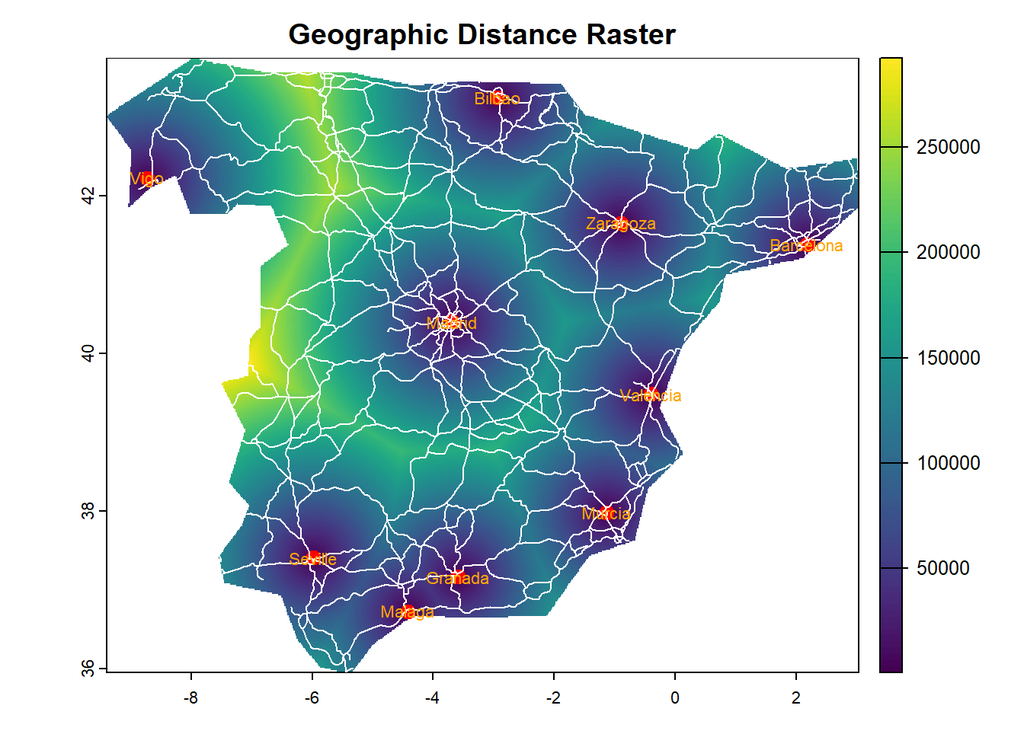

```r
# Apply the mask to get a cleaner graph.
geo_distance_raster_masked <- mask(geo_distance_raster, spain_border)


# Plot the computed distance raster
plot(geo_distance_raster_masked, main = "Geographic Distance Raster")

# Add city points to the plot
plot(st_geometry(city_points), add = TRUE, col = "red", pch = 20, cex = 2)


# Overlay roads to verify they are in **low friction zones**
plot(st_geometry(spain_roads_cropped), add = TRUE, col = "white")

# Label cities with their extracted values
text(st_coordinates(city_points), labels = city_raster_df$City, cex = 0.7, col = "orange")
```

Distances Between each pair of cities.

```r
# Compute distance matrix using terra
geo_distance_matrix <- distance(city_points_vect)

# Convert to a data frame for better visualization
geo_distance_df <- as.data.frame(as.matrix(geo_distance_matrix))

# Assign city names
rownames(geo_distance_df) <- spain_cities$NAMEASCII
colnames(geo_distance_df) <- spain_cities$NAMEASCII

# Print the full city-to-city distance matrix
print(geo_distance_df)
```

```
##             Madrid Barcelona  Seville   Bilbao Valencia Zaragoza    Malaga
## Madrid         0.0  506196.0 387665.4 322487.4 298406.5 272884.8 413661.84
## Barcelona 506196.0       0.0 829824.5 469415.2 304075.6 258047.7 770745.05
## Seville   387665.4  829824.5      0.0 698740.0 538873.2 642911.2 158182.17
## Bilbao    322487.4  469415.2 698740.0      0.0 468337.2 244424.5 736056.35
## Valencia  298406.5  304075.6 538873.2 468337.2      0.0 243723.8 467343.57
## Zaragoza  272884.8  258047.7 642911.2 244424.5 243723.8      0.0 626380.39
## Malaga    413661.8  770745.0 158182.2 736056.3 467343.6 626380.4      0.00
## Murcia    347866.2  472824.1 432445.5 604669.0 178863.2 408002.5 323261.91
## Granada   359448.8  683152.9 214042.5 677962.0 379294.9 549305.9  89254.34
## Vigo      468102.6  910901.3 584085.5 488439.3 764571.2 653051.9 714160.12
##             Murcia   Granada     Vigo
## Madrid    347866.2 359448.83 468102.6
## Barcelona 472824.1 683152.88 910901.3
## Seville   432445.5 214042.51 584085.5
## Bilbao    604669.0 677962.03 488439.3
## Valencia  178863.2 379294.86 764571.2
## Zaragoza  408002.5 549305.94 653051.9
## Malaga    323261.9  89254.34 714160.1
## Murcia         0.0 234976.24 800475.4
## Granada   234976.2      0.00 713669.7
## Vigo      800475.4 713669.69      0.0
```

Plotting smoothed distance distribution.

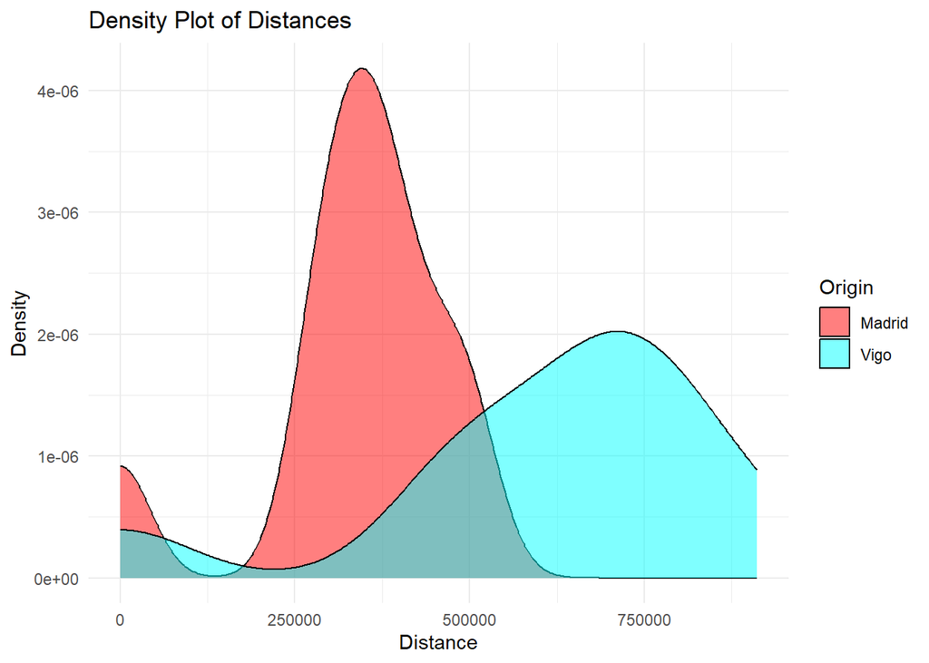

```r
sink(tempfile())
# Most Isolated City from Madrid:
geo_distance_df["Madrid"] %>%
  arrange('Madrid') %>%
  slice(2:2)

# Most Isolated City from Vigo:
geo_distance_df["Vigo"] %>%
  arrange('Vigo') %>%
  slice(2:2)
sink()

# Convert matrix to long format
geo_distance_long <- geo_distance_df %>%
  rownames_to_column(var = "origin") %>%
  pivot_longer(-origin, names_to = "destination", values_to = "distance") %>%
  filter(origin %in% c("Madrid", "Vigo"))  # Filter for Madrid and Vigo as origin

# Create the density plot
ggplot(geo_distance_long, aes(x = distance, fill = origin)) +
  geom_density(alpha = 0.5) +  # Use alpha for transparency
  scale_fill_manual(values = c("Madrid" = "red", "Vigo" = "cyan")) +
  labs(title = "Density Plot of Distances",
       x = "Distance",
       y = "Density",
       fill = "Origin") +
  theme_minimal()
```